# Implementing and testing the HAR-QREG model i R

## Introduction

In this R Markdown document we will implement the HAR-QREG model of [Haugom et al. (2016)](http://www.sciencedirect.com/science/article/pii/S1544612315001385) in R, and backtest the quantile/Value at Risk (VaR) predictions. Predicting VaR is essentially predicting quantiles and hence quantile regression is a natural choice when modelling VaR. The HAR-QREG model is a quantile regression model using short term, medium term and long term historical volatility (square root of 1 day, 5 days and 20 days average squared returns) as explanatory variables. This is of course heavily inspired by the HAR-RV model of [Corsi (2009)](https://www.scopus.com/record/display.uri?eid=2-s2.0-62849101579&origin=inward&txGid=a69b94b190edf2833685a89bf157a243).

Bellow we will predict the 5 % quantile (VaR) on daily returns from the DAX index, using a rolling window of 1000 days.

## Code

For implementing and testing the model we only need to load/install two packages. The [GAS](https://www.rdocumentation.org/packages/GAS/versions/0.2.4) package has some nice financial data in addition to implementation of the [Conditional Coverage test](https://www.jstor.org/stable/2527341?seq=1#page_scan_tab_contents) and the [Dynamic Quantile test](http://www.simonemanganelli.org/Simone/Research_files/caviarPublished.pdf). And of course the [quantreg](https://cran.r-project.org/web/packages/quantreg/index.html) package for quantile regression.

```r
library(GAS)
library(quantreg)
```

Loading the data set *StockIndices*, from the GAS package, which includes almost 10 years of daily data for three European Stock indices.

```r
data("StockIndices")
head(StockIndices)
```

```
##                   DAX     FTSEMIB       CAC40
## 2007-01-03  0.1524020 -0.12094156  0.10704220
## 2007-01-04 -0.2531840 -0.65012840 -0.52441005
## 2007-01-05 -1.2257191 -1.03157107 -0.58725705
## 2007-01-08  0.2196857  0.02246743 -0.16842312
## 2007-01-09  0.1025608  0.26131824  0.09387073
## 2007-01-10 -0.7254460 -0.56329368 -0.49682952
```

We will continue with the DAX index in this example and proceed with creating the three explanatory variables with use of the [filter function](https://stat.ethz.ch/R-manual/R-devel/library/stats/html/filter.html). Notice that by removing the last observation and include an *NA* in the beginning of the vectors, we get lagged observations. This means that the volatility estimates on a given row, is not estimated using the actual return on that row.

```r
y <- StockIndices[, "DAX"]
n <- length(y)

# Make data frame with explanatory variabels
df1 <- data.frame(y = y,
                  sigma1 = c( NA, sqrt(y^2)[-n] ), # Square root of yesterdays squared return
                  sigma5 = c( NA, sqrt(filter(y^2, rep(1/5, 5), sides = 1))[-n] ), # Square root of past 5 days average squared return
                  sigma20 = c( NA, sqrt(filter(y^2, rep(1/20, 20), sides = 1))[-n] ) # Square root of past 20 days average squared return
)

head(df1, 25)
```

```
##                      y     sigma1    sigma5   sigma20
## 2007-01-03  0.15240204         NA        NA        NA
## 2007-01-04 -0.25318399 0.15240204        NA        NA
## 2007-01-05 -1.22571907 0.25318399        NA        NA
## 2007-01-08  0.21968575 1.22571907        NA        NA
## 2007-01-09  0.10256079 0.21968575        NA        NA
## 2007-01-10 -0.72544604 0.10256079 0.5741944        NA
## 2007-01-11  1.82200638 0.72544604 0.6559789        NA
## 2007-01-12  0.26686829 1.82200638 1.0399180        NA
## 2007-01-15  0.39548298 0.26686829 0.8917375        NA
## 2007-01-16 -0.22188868 0.39548298 0.9037835        NA
## 2007-01-17 -0.22535474 0.22188868 0.9080572        NA
## 2007-01-18 -0.18041658 0.22535474 0.8540904        NA
## 2007-01-19  0.85660573 0.18041658 0.2684008        NA
## 2007-01-22 -0.89114367 0.85660573 0.4522720        NA
## 2007-01-23 -0.12538880 0.89114367 0.5762777        NA
## 2007-01-24  1.03431901 0.12538880 0.5704328        NA
## 2007-01-25 -0.42753474 1.03431901 0.7274612        NA
## 2007-01-26 -0.43609925 0.42753474 0.7478281        NA
## 2007-01-29  0.53173936 0.43609925 0.6712144        NA
## 2007-01-30  0.92081619 0.53173936 0.5901277        NA
## 2007-01-31  0.01296105 0.92081619 0.7174167 0.7061068
## 2007-02-01  0.91156271 0.01296105 0.5484133 0.7052900
## 2007-02-02  0.50200122 0.91156271 0.6560406 0.7319673
## 2007-02-05 -0.17005615 0.50200122 0.6653975 0.6879368
## 2007-02-06  0.02385694 0.17005615 0.6260897 0.6872335
```

After removing the rows with missing observations we may estimate and predict 5% VaR with a rolling window of 1000 trading days within a for-loop. For comparison we also include the empirical 5% quantile of the 1000-day window (often referred to as historical simulation).

```r
df1 <- na.omit(df1)
N <- nrow(df1)
# Rolling window one-day-ahead predictions with window of 1000 observations
win_size <- 1000 # Window size
pred0 <- numeric(N - win_size) # Historical quantiles
pred1 <- numeric(N - win_size) # HAR-QREG model
alpha <- 0.05 # Quantile to predict

for(r in win_size:(N -1)){
  rqfit <- rq(y ~ sigma1 + sigma5 + sigma20, data = df1[(r - win_size + 1):r, ], tau = alpha)

  pred0[r - win_size + 1] <- quantile(df1$y[(r - win_size + 1):r], probs = alpha)
  pred1[r - win_size + 1] <- predict(rqfit, df1[r + 1, ])
}

# A matrix with asset return and predicted quantiles
predmat <- cbind(Return = y[(win_size + 1):N], HS = pred0, HARQREG = pred1)
head(predmat)
```

```
##                 Return        HS   HARQREG
## 2010-12-08 -0.37259234 -2.494283 -1.651862
## 2010-12-09 -0.16800485 -2.494283 -1.536281
## 2010-12-10  0.60141589 -2.494283 -1.601008
## 2010-12-13  0.33087723 -2.494283 -1.449719
## 2010-12-14 -0.02831706 -2.494283 -1.632151
## 2010-12-15 -0.15707730 -2.494283 -1.729725
```

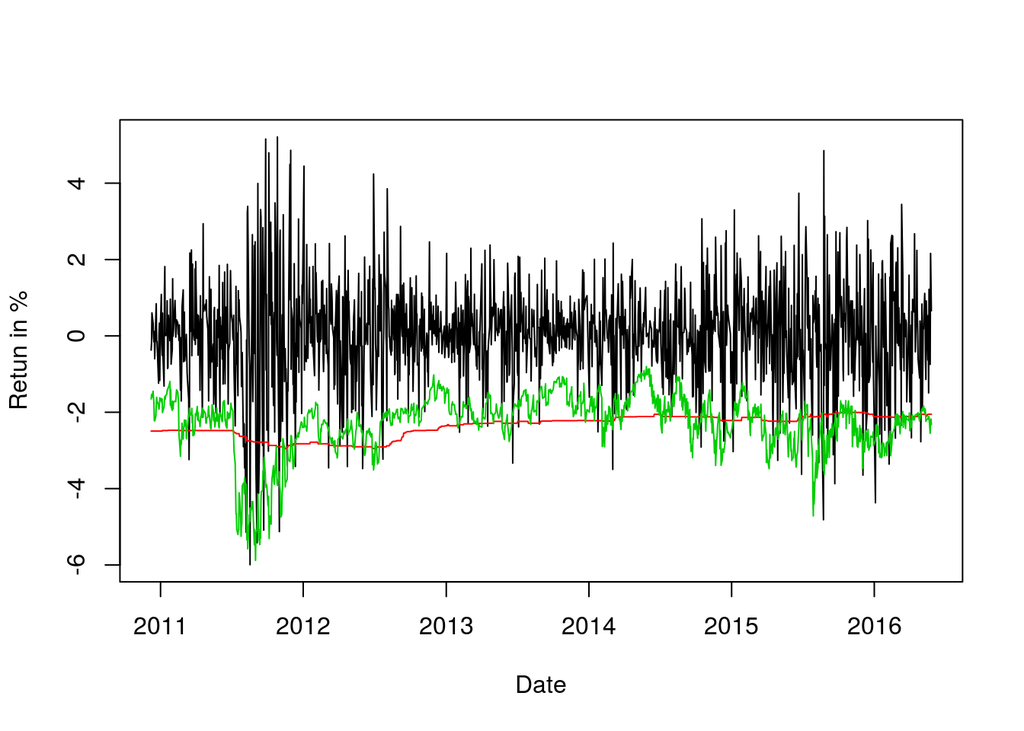

```r
plot(as.Date(rownames(predmat)), predmat[, "Return"], type = "l", ylab = "Retun in %", xlab = "Date")
lines(as.Date(rownames(predmat)), predmat[, "HS"], col = 2)
lines(as.Date(rownames(predmat)), predmat[, "HARQREG"], col = 3)
```

The red line is the historical 5% quantile and the green line is the predicted 5% VaR from the HAR-QREG model.

Finally we can use the [BacktestVaR function](https://www.rdocumentation.org/packages/GAS/versions/0.1.9/topics/BacktestVaR) to evaluate the predictions. We extract the P-values from the Conditional Coverage test and the Dynamic Quantile test. In both this tests the null-hypothesis is that the predicted quantiles are correct and that there is no dependence in whether the asset returns is above/bellow the predicted quantile. Hence a larger P-value gives us more confidence in the model.

Bellow the P-values are presented with a bar plot.

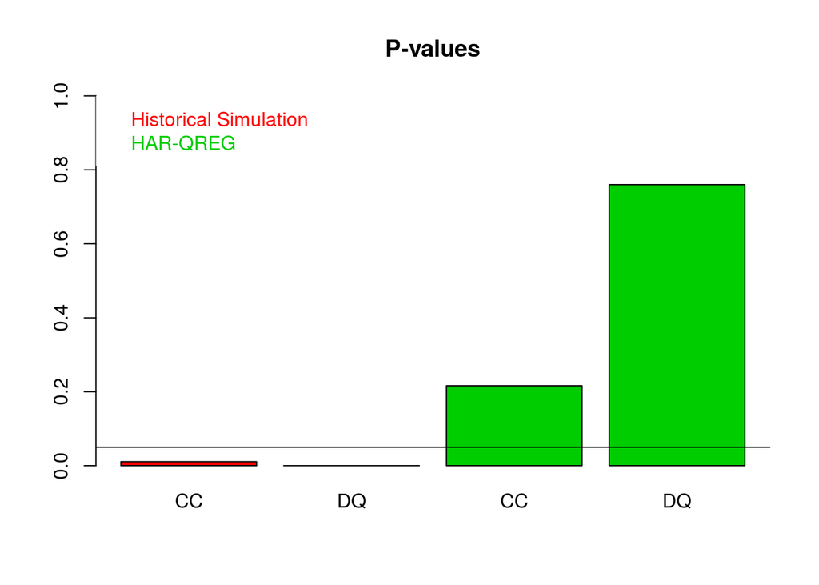

```r
btest0 <- BacktestVaR(data = predmat[, "Return"], VaR = predmat[, "HS"], alpha = alpha)
btest1 <- BacktestVaR(data = predmat[, "Return"], VaR = predmat[, "HARQREG"], alpha = alpha)

# A grafical presentation of P-values for Conditional Covareage test and Dynamic Quantile test
pval0 <- c("CC" = unname(btest0$LRcc[2]), "DQ" = btest0$DQ$pvalue)
pval1 <- c("CC" = unname(btest1$LRcc[2]), "DQ" = btest1$DQ$pvalue)

barplot(c(pval0, pval1), ylim = c(0, 1), col = c(2,2,3,3), main = "P-values")
abline(h = 0.05) # Illustrating a 5 % significance level
legend("topleft", legend = c("Historical Simulation", "HAR-QREG"), text.col = c(2,3),
       box.lty = 0)
```